# Introdução à economia

Aula 22 - Mercados de fatores de produção

Prof. Roberto de Freitas Neder

## Aula 22: roteiro

**Mercados de fatores de produção** · Mankiw, capítulo 18 · UnB

- Demanda por trabalho
- Oferta e equilíbrio
- Limites da concorrência
- Terra, capital e interdependência
- Conclusão
- Exercícios de concursos públicos

Use as setas para trocar de slide. Nas páginas longas, role o conteúdo. As respostas das atividades ficam fechadas até o clique.

## 01 - Quem recebe a renda da produção?

Produzir exige trabalho, terra, instalações, equipamentos e outros recursos. Os pagamentos pelo uso desses fatores formam parte da renda gerada na economia.

O capítulo estende a análise de oferta e demanda aos **mercados de fatores de produção**. Começaremos pelo trabalho e depois estudaremos terra e capital.

O modelo competitivo oferece uma referência. Suas conclusões dependem de hipóteses sobre concorrência, informação e mobilidade, que precisam ser explicitadas.

**Base:** Mankiw, capítulo 18, *The Markets for the Factors of Production*, pp. 361 a 381. PDF: pp. 390 a 410.

← Menu

## 02 - Uma demanda derivada

Uma padaria contrata trabalhadores para produzir pães que espera vender. Por isso, a demanda por trabalho depende da demanda pelo produto e das condições de produção.

Chamamos essa relação de **demanda derivada**. O mesmo raciocínio vale para máquinas, terra e outros insumos.

Se a demanda pelo produto final muda, o preço ou a quantidade vendida pode mudar e alterar a conveniência de contratar.

O trabalhador participa de uma relação social e institucional mais ampla. O modelo econômico isola uma dimensão: a decisão da firma sobre a quantidade de serviços de trabalho.

← Menu

## 03 - A firma competitiva

Assumiremos uma empresa que maximiza lucro e toma como dados tanto o preço de venda $P$ quanto o salário por trabalhador $W$.

Ela não consegue elevar seu preço sem perder compradores nem reduzir unilateralmente o salário de mercado sem perder trabalhadores.

No curto prazo do exemplo, terra e equipamentos estão fixos. A decisão é quantos trabalhadores contratar.

$$\pi=P\,Q(L)-WL-\text{outros custos}$$

A contratação depende da receita adicional gerada pelo trabalhador em comparação ao custo adicional de empregá-lo.

← Menu

## 04 - Função de produção

Uma função de produção relaciona a quantidade utilizada de fatores ao produto possível, dada a tecnologia.

**Exemplo didático, por período:**

| Trabalhadores $L$ | Produto $Q$ | Produto marginal $PMg_L$ |
| --- | --- | --- |
| 0 | 0 | Não se aplica |
| 1 | 100 | 100 |
| 2 | 180 | 80 |
| 3 | 240 | 60 |
| 4 | 280 | 40 |
| 5 | 300 | 20 |

O produto marginal é o acréscimo de produção ao adicionar uma unidade de trabalho, mantendo os demais fatores constantes.

← Menu

## 05 - Produto marginal decrescente

$$PMg_L=\frac{\Delta Q}{\Delta L}$$

Com equipamentos e espaço fixos, trabalhadores adicionais passam a disputar os mesmos recursos. O produto total continua aumentando, mas os acréscimos diminuem no exemplo.

**Produto marginal decrescente não significa produto total decrescente.** Para que o total caia, o produto marginal precisaria ser negativo.

Também não significa que o trabalhador recém-contratado tenha menor capacidade pessoal. O resultado pode decorrer da combinação de fatores disponível para toda a equipe.

← Menu

## 06 - Produção e acréscimos

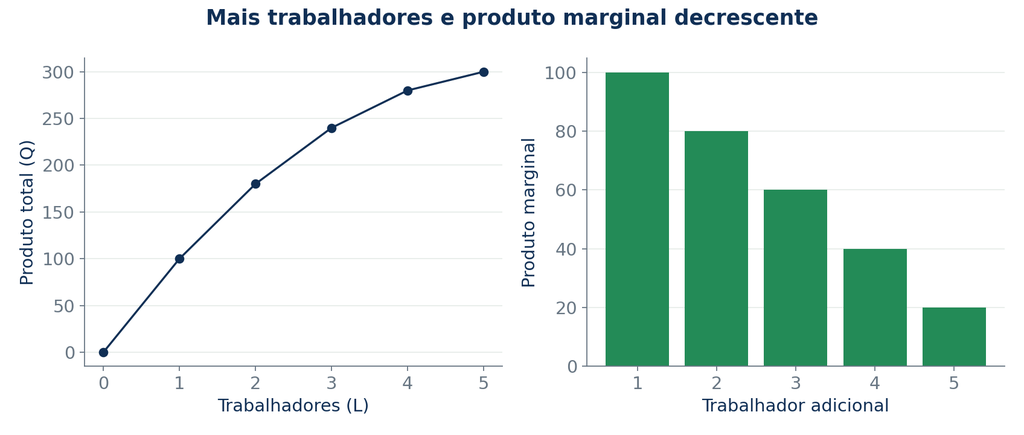

Dois painéis mostram o produto total crescente e o produto marginal decrescente da tabela de trabalhadores.

Fonte: elaboração didática. Dados hipotéticos, salvo indicação expressa.

A inclinação da função de produção representa o produto marginal. Quanto menor o acréscimo de produção por trabalhador adicional, mais horizontal fica a curva do produto total.

← Menu

## 07 - Valor do produto marginal

Para comparar produto adicional com salário, precisamos expressá-lo em dinheiro:

$$VPMg_L=P\times PMg_L$$

Se cada unidade do produto vale R$ 2, os produtos marginais de 100, 80, 60, 40 e 20 geram valores marginais de R$ 200, 160, 120, 80 e 40.

O quarto trabalhador acrescenta 40 unidades, que geram receita de R$ 80. Isso não informa a receita média por trabalhador nem a receita total da empresa.

A igualdade entre preço e receita marginal depende da concorrência no mercado do produto.

← Menu

## 08 - A contratação que maximiza lucro

Com salário de R$ 100 por período:

| Trabalhador adicional | Receita adicional | Custo adicional | Variação do lucro |
| --- | --- | --- | --- |
| Primeiro | 200 | 100 | +100 |
| Segundo | 160 | 100 | +60 |
| Terceiro | 120 | 100 | +20 |
| Quarto | 80 | 100 | -20 |

A firma contrata três trabalhadores. O quarto reduziria o lucro.

Em um modelo contínuo com solução interior, a condição é $VPMg_L=W$. Com unidades discretas, contrata-se até o último acréscimo cujo benefício cobre o custo.

← Menu

## 09 - Salário nominal e salário real

$$P\times PMg_L=W\quad\Rightarrow\quad PMg_L=\frac{W}{P}$$

$W$ é o salário em dinheiro. $W/P$ expressa o salário em unidades do produto da firma.

Na referência competitiva, o salário real iguala o produto marginal. Isso não é uma regra universal de pagamento observada em qualquer mercado.

Se a firma possui poder de mercado no produto, a receita marginal pode ser menor que o preço. A condição de demanda por trabalho passa a envolver **receita do produto marginal**, $RMg\times PMg_L$.

← Menu

## 10 - Demanda por trabalho e oferta do produto

Se trabalho é o fator variável e o salário é dado:

$$CMg=\frac{W}{PMg_L}$$

A condição $P=CMg$ implica $P\times PMg_L=W$. Assim, a decisão de produção e a decisão de contratação são duas formas de descrever o mesmo ajuste da firma competitiva.

Um produto marginal maior reduz o trabalho necessário para uma unidade adicional e, portanto, reduz seu custo marginal.

Esse resultado conecta a aula aos capítulos de custos e firmas competitivas. Vale sob as hipóteses explicitadas, sem ignorar outros custos variáveis quando eles existirem.

← Menu

## 11 - Por que a demanda por trabalho cai?

Com produto marginal decrescente e preço do produto dado, o valor do produto marginal cai à medida que a firma contrata mais.

Por isso, sua curva de demanda por trabalho é decrescente no intervalo relevante: salários menores tornam rentável contratar uma quantidade maior.

Uma mudança do salário gera movimento ao longo dessa curva. Mudanças em preço do produto, tecnologia ou quantidade dos demais fatores podem deslocá-la.

A demanda do mercado agrega as decisões das empresas, mas ajustes do preço do produto podem tornar essa agregação mais complexa que uma soma mecânica.

← Menu

## 12 - Deslocamentos da demanda

| Mudança | Mecanismo possível |
| --- | --- |
| Preço do produto aumenta | Cada unidade adicional gera mais receita |
| Tecnologia aumenta o produto marginal do trabalho | Contratar torna-se mais rentável a dado salário |
| Mais capital complementar | Trabalhadores dispõem de mais recursos produtivos |
| Tecnologia substitui determinadas tarefas | A demanda por essas tarefas pode diminuir |

Tecnologia não desloca necessariamente a demanda de todos os tipos de trabalho no mesmo sentido. É preciso considerar substituição, complementaridade e expansão da produção.

← Menu

## 13 - Jogo rápido: contratar mais um?

Uma firma competitiva vende cada unidade por R$ 5. Um trabalhador adicional produziria 30 unidades e custaria R$ 120 no período.

1. Qual é o valor do produto marginal?
2. A contratação aumenta o lucro?
3. Se o preço cair para R$ 3, mantendo esse produto marginal, qual é a nova decisão?

**Conferir respostas**

1. R$ 150. 2. Sim, em R$ 30. 3. A receita adicional cai para R$ 90, abaixo do custo de R$ 120. A contratação reduziria o lucro em R$ 30, mantidos os demais custos.

← Menu

## 14 - Trabalho e tempo disponível

Oferecer mais horas de trabalho remunerado reduz o tempo disponível para outras atividades. O salário mede o custo de oportunidade de uma hora fora desse trabalho.

No modelo simplificado, a pessoa distribui tempo entre trabalho e lazer. Na vida concreta, parte do tempo envolve cuidado e trabalho doméstico, que não são lazer.

Condições de saúde, transporte, responsabilidades familiares e regras de jornada limitam as escolhas possíveis.

A oferta de trabalho representa decisões condicionadas por essas restrições, não uma liberdade ilimitada de escolher qualquer quantidade de horas.

← Menu

## 15 - Efeitos renda e substituição

Um salário maior torna mais caro abrir mão de uma hora de trabalho. Esse **efeito substituição** estimula mais trabalho remunerado.

Ao mesmo tempo, a renda maior permite desejar mais tempo livre, se lazer for um bem normal. Esse **efeito renda** pode reduzir as horas oferecidas.

O saldo é ambíguo para um indivíduo. Em certos intervalos, sua oferta pode se curvar para trás.

O capítulo trabalha principalmente com uma oferta de mercado crescente, que também incorpora entrada de pessoas e mobilidade entre ocupações. Não confunda essa hipótese com uma lei sobre cada trabalhador.

← Menu

## 16 - O que desloca a oferta?

Mudanças de preferências, oportunidades em outros mercados e migração podem alterar a oferta de trabalho a cada salário.

Se uma ocupação alternativa se torna mais atraente, parte dos trabalhadores pode sair do mercado analisado. Creches e transporte acessível também podem ampliar a possibilidade de participação.

Uma mudança do próprio salário é movimento ao longo da curva. Uma mudança das condições que determinam a oferta desloca a curva.

É preciso definir o mercado: uma cidade, uma ocupação ou a economia inteira. O mesmo evento pode atuar de formas distintas em cada recorte.

← Menu

## 17 - Equilíbrio competitivo

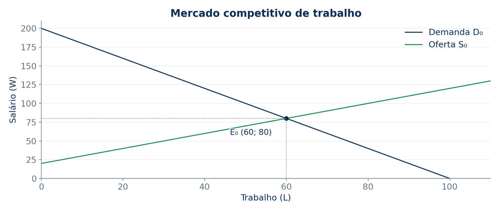

Demanda e oferta de trabalho se encontram em L igual a 60 e salário igual a 80 unidades monetárias por período.

Fonte: elaboração didática. Dados hipotéticos, salvo indicação expressa.

No exemplo, $D:W=200-2L$ e $S:W=20+L$. Igualando, $L^*=60$ e $W^*=80$.

O salário equilibra oferta e demanda. Sob as hipóteses competitivas, também corresponde ao valor do produto marginal no ponto de contratação.

← Menu

## 18 - Ampliação da oferta de trabalho

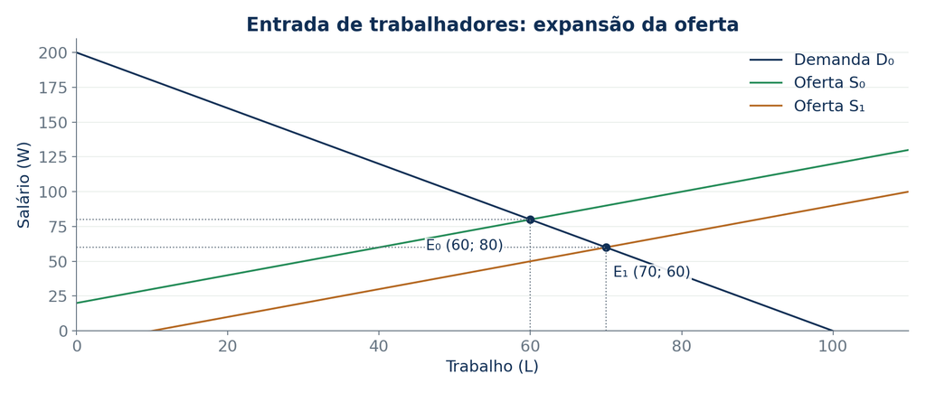

Oferta de trabalho desloca-se à direita, reduzindo o salário de 80 para 60 e aumentando emprego de 60 para 70, com demanda fixa.

Fonte: elaboração didática. Dados hipotéticos, salvo indicação expressa.

Com $S_1:W=-10+L$, o equilíbrio passa a $L=70$ e $W=60$.

É um exercício de equilíbrio parcial. Uma migração também pode ampliar consumo, empreendedorismo e demanda por trabalho. O resultado completo depende desses efeitos, do horizonte e da complementaridade entre trabalhadores.

← Menu

## 19 - Ampliação da demanda de trabalho

[figure not shown]

Demanda por trabalho desloca-se à direita, aumentando salário e emprego, com oferta fixa.

Fonte: elaboração didática. Dados hipotéticos, salvo indicação expressa.

Com $D_1:W=240-2L$, a oferta original produz $L\approx73{,}33$ e $W\approx93{,}33$.

Um aumento do preço do produto ou da produtividade pode gerar esse deslocamento. A explicação deve identificar qual determinante mudou e por que a contratação ficou mais atraente.

← Menu

## 20 - Produtividade e salários

O capítulo relaciona aumentos históricos da produtividade a maiores salários reais. No modelo competitivo, maior produto marginal eleva a demanda por trabalho.

Mas produtividade média agregada e remuneração de uma pessoa não são medidas idênticas. Composição setorial, preços, benefícios, poder de negociação e distribuição entre trabalho e capital afetam a comparação.

É possível que a economia produza mais por hora sem que todos recebam proporcionalmente mais.

Para avaliar uma afirmação empírica, confira população, período, deflator e definição de remuneração usados nas duas séries.

← Menu

## 21 - Poder de monopsônio

Uma empresa possui poder de monopsônio quando enfrenta restrições à mobilidade dos trabalhadores e consegue influenciar a remuneração necessária para contratar.

Se precisa aumentar o salário de todos para atrair mais uma pessoa, o custo marginal de contratação fica acima do salário pago ao último trabalhador.

A firma escolhe emprego onde **despesa marginal de trabalho iguala a receita do produto marginal**, e paga o salário indicado pela oferta.

Nesse modelo, salário e emprego podem ficar abaixo dos valores competitivos. Fricções e pouca concorrência entre empregadores também podem gerar poder de compra sem existir um único contratante literal.

← Menu

## 22 - Monopsônio no gráfico

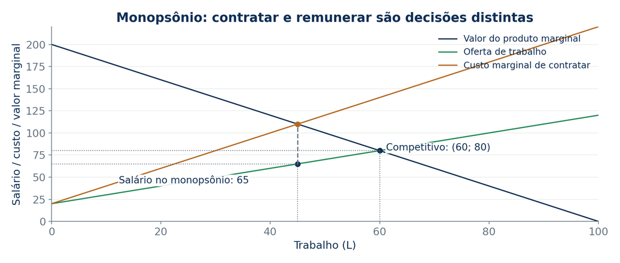

Oferta W igual a 20 mais L, despesa marginal igual a 20 mais 2L e valor marginal igual a 200 menos 2L; monopsônio contrata 45 e paga 65, contra 60 e 80 na concorrência.

Fonte: elaboração didática. Dados hipotéticos, salvo indicação expressa.

O cruzamento da despesa marginal com a demanda determina $L_m=45$. A oferta indica $W_m=65$. O salário não é lido na curva de despesa marginal.

← Menu

## 23 - Terra e capital físico

A demanda por serviços de terra e capital também é derivada da produção. A firma compara o valor do produto marginal do fator com o custo de utilizá-lo.

Capital físico inclui equipamentos e estruturas. Dinheiro e títulos são ativos financeiros, não máquinas por definição.

É importante separar **estoque do bem** e **fluxo de serviços**. Uma máquina é um estoque. Seu uso durante um mês fornece um fluxo de serviços produtivos.

O mesmo bem pode ser utilizado pelo proprietário ou alugado. A existência de um aluguel explícito não é condição para que haja custo de oportunidade.

← Menu

## 24 - Preço de compra e de aluguel

O preço de aluguel remunera o uso de um fator por um intervalo. O preço de compra dá acesso à propriedade e aos serviços futuros que ela pode gerar.

Na referência competitiva:

$$Aluguel_K=P\times PMg_K\qquad Aluguel_N=P\times PMg_N$$

O valor de compra depende dos rendimentos futuros esperados, depreciação, risco e taxa usada para compará-los ao presente.

Uma taxa de aluguel de R$ 2.000 por mês e um preço de compra de R$ 200.000 são grandezas diferentes. Não as coloque no mesmo eixo sem definir a unidade.

← Menu

## 25 - Renda da terra e oferta limitada

Quando a oferta de uma categoria de terra é muito pouco sensível ao preço, maior demanda pode elevar principalmente o aluguel.

O estoque físico de território é limitado, mas a oferta economicamente utilizável de uma localização ou finalidade depende de infraestrutura, regras de uso e conversão entre atividades.

Não se deve presumir que toda oferta de terra seja perfeitamente vertical em qualquer mercado.

Mudanças na produtividade do solo, no preço da produção agrícola ou no acesso a centros consumidores modificam o valor de seus serviços.

← Menu

## 26 - Os fatores são interdependentes

Mais máquinas podem elevar a produtividade dos trabalhadores que as utilizam. Mais trabalhadores para uma quantidade fixa de terra podem elevar o produto marginal da terra e reduzir o produto marginal do trabalho.

Complementaridade e substituição determinam o sinal de cada relação. Um equipamento pode substituir uma tarefa e complementar outra.

Por isso, um choque na oferta de um fator pode alterar a remuneração dos demais.

**A contribuição marginal depende da combinação produtiva.** Ela não mede uma contribuição isolada, independente da sociedade, da tecnologia e dos outros fatores.

← Menu

## 27 - A Peste Negra como exemplo histórico

O capítulo utiliza a Peste Negra para ilustrar um choque de escassez de trabalho na Europa medieval.

Com menos trabalhadores em relação à terra, o trabalho tornou-se relativamente mais escasso. O mecanismo apresentado associa essa mudança a salários maiores e rendimentos da terra menores.

A terra, com menos trabalho para cultivá-la, passou a gerar menor produto marginal. Os sobreviventes encontraram condições diferentes de oferta e demanda.

O exemplo explica interdependência entre fatores. Não autoriza reduzir uma tragédia humana a um ganho econômico agregado nem ignorar coerção e instituições históricas.

← Menu

## 28 - Jogo rápido: efeitos entre fatores

Uma região recebe equipamentos que complementam o trabalho local. Mantenha a oferta de trabalho e o preço do produto constantes.

1. O que ocorre com o produto marginal do trabalho?
2. Qual curva do mercado de trabalho se desloca?
3. Qual o resultado competitivo sobre salário e emprego?

**Conferir respostas**

1. Aumenta, pela hipótese de complementaridade. 2. A demanda por trabalho se desloca para a direita. 3. Salário e emprego aumentam com oferta crescente. Se a tecnologia substituísse o tipo de trabalho analisado, o efeito poderia ser diferente.

← Menu

## 29 - Conclusão: produtividade, escassez e instituições

A demanda por fatores deriva do valor da produção que eles ajudam a realizar. No modelo competitivo, a contratação compara valor marginal e custo do fator.

Oferta, tecnologia e disponibilidade dos demais fatores alteram equilíbrio e remuneração. Terra, capital e trabalho são interdependentes.

**As hipóteses de concorrência delimitam as conclusões.** Monopsônio, fricções, discriminação e instituições podem modificar salários e emprego.

A teoria descreve mecanismos de distribuição. Para discutir justiça distributiva e condições de trabalho, também precisamos dos critérios e evidências examinados nas demais aulas.

← Menu

## Exercícios de concursos públicos

Oito exercícios selecionados. Nos itens de julgamento, use **C (certo/verdadeiro)** ou **E (errado/falso)**. Leia os enunciados antes de abrir as respostas. As fontes e as adaptações estão identificadas em cada questão.

### Questão 01

CESPE, Câmara dos Deputados, Analista Legislativo / Assistente Técnico, FC de Consultor Legislativo, Área V, 2002 · questão 69, 1º item

Com concorrência nos mercados de produto e de trabalho, qual condição caracteriza a contratação ótima de uma firma?

1. W igual ao produto médio
2. W/P igual ao produto marginal do trabalho
3. W/P igual à produção total
4. W sempre igual a zero
5. Produto marginal igual ao lucro total

Adaptação didática de um item C/E para múltipla escolha; alternativas criadas para a aula. O item original tem gabarito C.

[Prova original](https://cdn.cebraspe.org.br/concursos/_antigos/2003/camaradosdeputados/ARQUIVOS/area_05.pdf) · [Gabarito oficial](https://cdn.cebraspe.org.br/concursos/_antigos/2003/CAMARADOSDEPUTADOS/Arquivos/Gab_Def_CD.pdf)

Resposta comentada

### Questão 02

CESPE, Câmara dos Deputados, Analista Legislativo / Assistente Técnico, FC de Consultor Legislativo, Área V, 2002 · questão 69, 2º item

Quando o salário real aumenta, o nível de emprego também se eleva, pois os maiores salários levam a um aumento do consumo, que se traduz em maior demanda de trabalho.

**( ) C ( ) E**

Item original C/E, com normalização de espaçamento. A prova autoriza reprodução com indicação da fonte.

[Prova original](https://cdn.cebraspe.org.br/concursos/_antigos/2003/camaradosdeputados/ARQUIVOS/area_05.pdf) · [Gabarito oficial](https://cdn.cebraspe.org.br/concursos/_antigos/2003/CAMARADOSDEPUTADOS/Arquivos/Gab_Def_CD.pdf)

Resposta comentada

### Questão 03

CESPE, Câmara dos Deputados, Analista Legislativo / Assistente Técnico, FC de Consultor Legislativo, Área V, 2002 · questão 69, 3º item

A produtividade marginal do trabalho é positiva e crescente.

**( ) C ( ) E**

Item original C/E, com normalização de espaçamento. A prova autoriza reprodução com indicação da fonte.

[Prova original](https://cdn.cebraspe.org.br/concursos/_antigos/2003/camaradosdeputados/ARQUIVOS/area_05.pdf) · [Gabarito oficial](https://cdn.cebraspe.org.br/concursos/_antigos/2003/CAMARADOSDEPUTADOS/Arquivos/Gab_Def_CD.pdf)

Resposta comentada

### Questão 04

CESPE, Câmara dos Deputados, Analista Legislativo / Assistente Técnico, FC de Consultor Legislativo, Área V, 2002 · questão 69, 5º item

A relação entre quantidade de trabalho oferecida e salário real pode ser constante, crescente ou decrescente.

**( ) C ( ) E**

Item original C/E, com normalização de espaçamento. A prova autoriza reprodução com indicação da fonte.

[Prova original](https://cdn.cebraspe.org.br/concursos/_antigos/2003/camaradosdeputados/ARQUIVOS/area_05.pdf) · [Gabarito oficial](https://cdn.cebraspe.org.br/concursos/_antigos/2003/CAMARADOSDEPUTADOS/Arquivos/Gab_Def_CD.pdf)

Resposta comentada

### Questão 05

CESPE, Senado Federal, Consultor Legislativo, Área 14, 2002 · questão 63, 2º item

Os trabalhadores possuem o mesmo salário de reserva (reservation wages), que pode ser representado pela curva de oferta de mão-de-obra.

**( ) C ( ) E**

Item original C/E, com normalização de espaçamento. A prova autoriza reprodução com indicação da fonte.

[Prova original](https://cdn.cebraspe.org.br/concursos/_antigos/2002/senado/Arquivos/area_14_LEGISL_1Et.pdf) · [Gabarito oficial](https://cdn.cebraspe.org.br/concursos/_antigos/2002/senado/Arquivos/Gab_Def-SENADO.pdf)

Resposta comentada

### Questão 06

CESPE, Senado Federal, Consultor Legislativo, Área 14, 2002 · questão 63, 3º item

No curto prazo, a curva de demanda por mão-de-obra de uma firma pode ser caracterizada como um segmento da curva do produto marginal do trabalho.

**( ) C ( ) E**

Item original C/E, com normalização de espaçamento. A prova autoriza reprodução com indicação da fonte.

[Prova original](https://cdn.cebraspe.org.br/concursos/_antigos/2002/senado/Arquivos/area_14_LEGISL_1Et.pdf) · [Gabarito oficial](https://cdn.cebraspe.org.br/concursos/_antigos/2002/senado/Arquivos/Gab_Def-SENADO.pdf)

Resposta comentada

### Questão 07

CESPE, Senado Federal, Consultor Legislativo, Área 14, 2002 · questão 63, 4º item

Um aumento de salário sempre induzirá a uma elevação no número de horas que cada trabalhador estará disposto a ofertar.

**( ) C ( ) E**

Item original C/E, com normalização de espaçamento. A prova autoriza reprodução com indicação da fonte.

[Prova original](https://cdn.cebraspe.org.br/concursos/_antigos/2002/senado/Arquivos/area_14_LEGISL_1Et.pdf) · [Gabarito oficial](https://cdn.cebraspe.org.br/concursos/_antigos/2002/senado/Arquivos/Gab_Def-SENADO.pdf)

Resposta comentada

### Questão 08

Cebraspe, SEE/DF, Analista de Gestão Educacional, Economia, 2017 · questão 90

Dividir o produto total pela quantidade de trabalho fornece a produtividade marginal.

**( ) C ( ) E**

Redação sintetizada para uso didático; dados e resposta preservados.

[Prova original](https://cdn.cebraspe.org.br/concursos/SEE_16_DF/arquivos/291_SEEDF_007_01.pdf) · [Gabarito oficial](https://cdn.cebraspe.org.br/concursos/SEE_16_DF/arquivos/Gab_Definitivo_291_SEEDF_007_01.pdf)

Resposta comentada

**Gabarito resumido e resoluções comentadas**

| Questão | 01 | 02 | 03 | 04 | 05 | 06 | 07 | 08 |
| --- | --- | --- | --- | --- | --- | --- | --- | --- |
| Resposta | B | E | E | C | E | C | E | E |

**Questão 01: B**

$W=P\,PMg_L$, ou $W/P=PMg_L$. O custo de contratar uma unidade de trabalho iguala o valor do produto adicional. Não se iguala salário ao produto médio.

Voltar ao enunciado

**Questão 02: E**

Mantidos preço do produto, capital e tecnologia, salário real maior reduz a quantidade de trabalho demandada ao longo da curva. O enunciado mistura esse problema da firma com um possível efeito macroeconômico sobre consumo, que não é a condição do modelo utilizado.

Voltar ao enunciado

**Questão 03: E**

Na região relevante do modelo estudado, acrescentar trabalho a uma quantidade fixa dos demais fatores gera produtividade marginal decrescente. Positiva significa acrescentar produto; crescente significaria acrescentar cada vez mais, o que é outra propriedade.

Voltar ao enunciado

**Questão 04: C**

A resposta individual depende da interação entre efeitos substituição e renda. Maior salário torna o lazer mais caro, mas permite consumir mais lazer se ele for normal. Por isso não se exige inclinação positiva em todos os trechos.

Voltar ao enunciado

**Questão 05: E**

Salário de reserva é o mínimo necessário para uma pessoa aceitar determinado emprego, dadas suas alternativas. Pessoas diferem em preferências, rendas, custos de deslocamento, cuidado e condições de trabalho.

Voltar ao enunciado

**Questão 06: C**

Em unidades reais, a demanda de trabalho acompanha o trecho relevante de $PMg_L$. Em unidades monetárias, usa-se $P\,PMg_L$, o valor do produto marginal. O resultado requer firma tomadora de preços e a região em que contratar é economicamente viável.

Voltar ao enunciado

**Questão 07: E**

O efeito substituição incentiva trocar lazer por trabalho, mas o efeito renda pode operar no sentido oposto. A palavra “sempre” transforma em regra universal uma resposta que depende de preferências e condições.

Voltar ao enunciado

**Questão 08: E**

Essa divisão mede produtividade média: $PMe_L=Q/L$. A marginal é $PMg_L=\Delta Q/\Delta L$ e mede o produto adicional obtido ao acrescentar trabalho, mantendo os demais fatores constantes.

Voltar ao enunciado

← Menu